# Cognitive Modelling lab 2

We load the starting data

```r
setwd(dirname(rstudioapi::getActiveDocumentContext()$path))
NeuralResponses <- read.table("NeuralResponses")
```

Simulating the noise and generating data for 12 subjects in a list called subjects

```r
y_count <- nrow(NeuralResponses)
x_count <- ncol(NeuralResponses)

subjects <- list()
for (index in 1:12){
  noise_dist <- matrix(rnorm(x_count*y_count,mean=0,sd=1),y_count,x_count)
  data_with_noise <- noise_dist + NeuralResponses
  subjects[[length(subjects)+1]] <- data_with_noise
}
```

**Question 1**: Discuss with your group, then describe to your teacher, some reasons why each method may be more suitable for different data types or research questions.

Correlation part, one may be more suited for noisy data, the other for non noisy data? IDK yet

We transpose the data, so its 92 x 92 not 100 x 100 (for images, not recording sites)

First dissimilarity matrix in the list is for the original data, next 12 are for simulated data.

```r
library(Hmisc)
dissimilarities <- list()
dissimilarities[[length(dissimilarities)+1]] <- 1 -  rcorr(t(as.matrix(NeuralResponses)), type="pearson")$r
for (subject in 1:12){
  dissimilarities[[length(dissimilarities)+1]] <- 1 -  rcorr(t(as.matrix(subjects[[subject]])), type="pearson")$r
  # returns the matrix of correlations, thats what $r is at the end
}
```

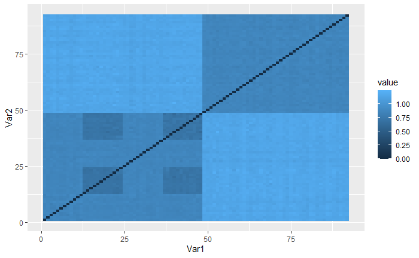

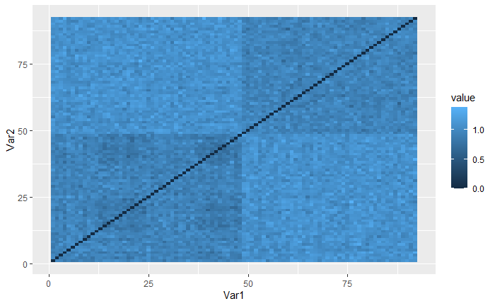

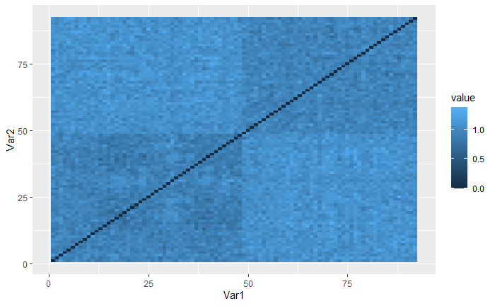

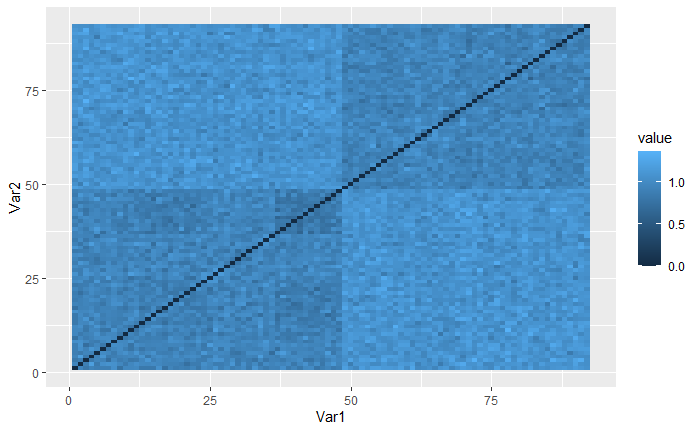

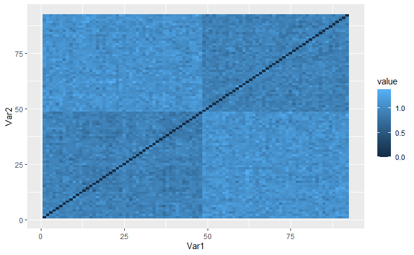

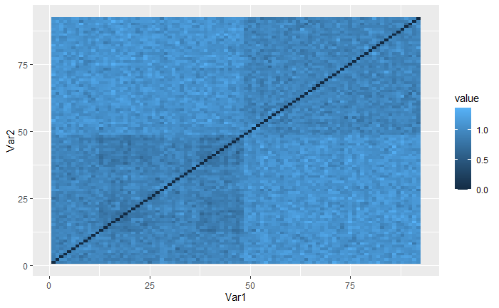

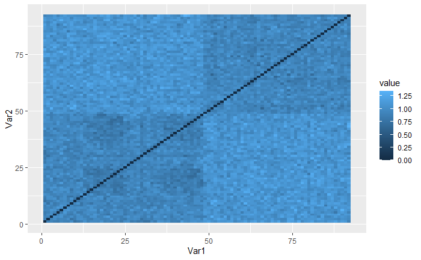

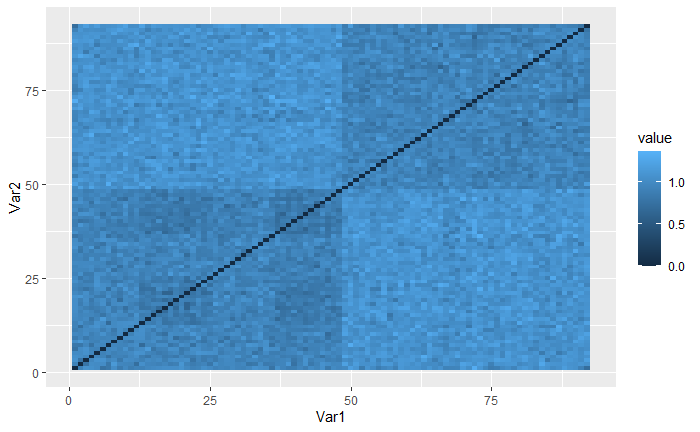

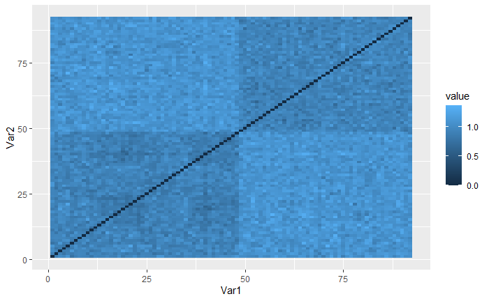

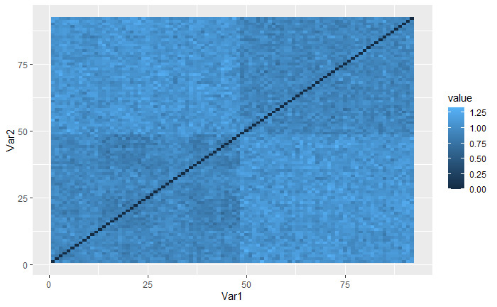

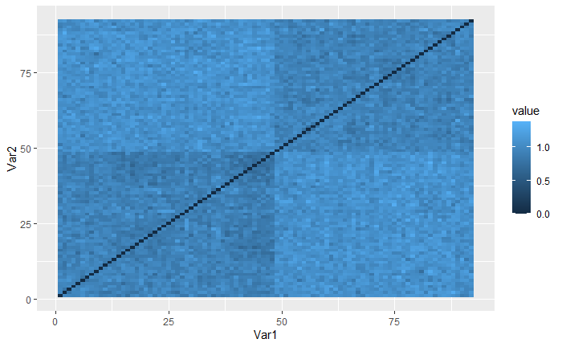

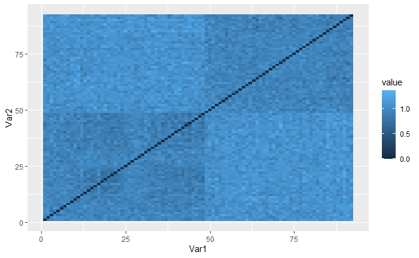

[1 more figures not shown]

```r
library(ggplot2)
library(reshape2)

for (subject_index in 1:13){
  melted <- melt(dissimilarities[[subject_index]])
  print(ggplot(as.data.frame(melted),aes(x=Var1,y=Var2,fill=value)) + geom_tile())
}
```

**Question 2**: Discuss with your group, then describe to your teacher: how do these two RDMs differ? More noise, thats how they differ?

Now we make averages (Average across 12 participants, Average for each individual of the 12 participants, average from the original data)

```r
total <- 0
averages_vect <- c(rep(0,times=12))
for (i in 2:13){
  total <- total + dissimilarities[[i]]
  averages_vect[i-1] <- sum(dissimilarities[[i]])/92/92
}
print("Average across 12 participants")
```

```
[1] "Average across 12 participants"
```

```r
print(avg_total_12 <- sum(total)/12/92/92)
```

```
[1] 0.9909809
```

```r
print("Average for the original data")
```

```
[1] "Average for the original data"
```

```r
print(avg_total_original <- mean(dissimilarities[[1]]))
```

```
[1] 0.9918187
```

```r
print("Average for each individual subject 1-12")
```

```
[1] "Average for each individual subject 1-12"
```

```r
print(averages_vect)
```

```
 [1] 0.9902459 0.9905803 0.9913047 0.9905552 0.9897969 0.9891146 0.9902854 0.9924895
 [9] 0.9937891 0.9906114 0.9905840 0.9924143
```

And now for the averaged heatmap (first) compared to the original one (second)

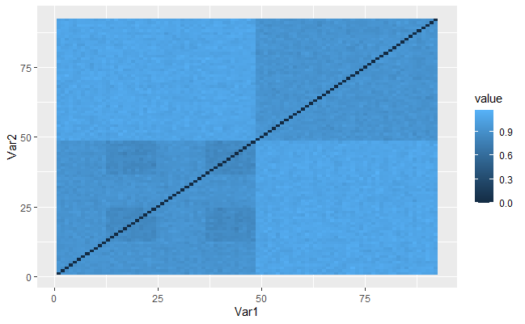

```r
melted <- melt(total/12)
  print(ggplot(as.data.frame(melted),aes(x=Var1,y=Var2,fill=value)) + geom_tile())
```

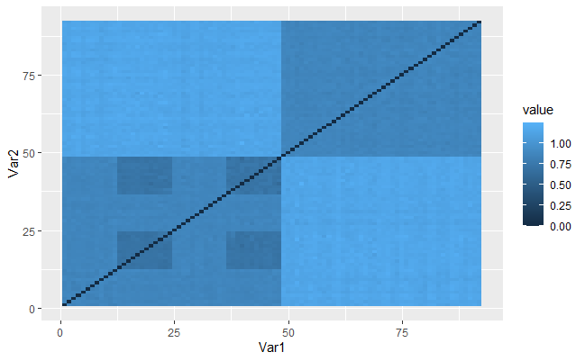

```r
  melted <- melt(dissimilarities[[1]])
  print(ggplot(as.data.frame(melted),aes(x=Var1,y=Var2,fill=value)) + geom_tile())
```

**Question 3**: Discuss with your group, then describe to your teacher: How do these differ, and why? (Question 3, 2 points). Keep the resulting ‘average subject’ RDM for later.

These averages differ in that the ones derived from subjects have noise added to them, so the values have a standard deviation

**NEW SECTION**

**Question 4**:

We load the data again

```r
CategoryVectors <- read.table("CategoryVectors")
CategoryLabels <- read.table("CategoryLabels")
NeuralResponses <- read.table("NeuralResponses")
avg_participant <- total/12
#dissimilarities[[i]] i is from 1 to 13, first one is original one, last 12 ones are simulated ones
```

Ignore this, messing around

```r
dissm_vectors <- 1 - rcorr(t(as.matrix(CategoryVectors)), type="pearson")$r
dissm_categories <- 1 - rcorr(as.matrix(CategoryVectors), type="pearson")$r
```

Creating mask to get pairs with disimmilarity 0 and 1 based on the first category (animacy)

```r
column_1x <- CategoryVectors$V1
column_1y <- CategoryVectors$V1

# I spent 45 minutes looking for a function then gave up and did it on my own
# But theres probably a function somewhere
col1_dsmatrix <- matrix(0,length(column_1x),length(column_1y))
for (ind_y in 1:length(column_1y)){
  for (ind_x in 1:length(column_1x)){
    if(column_1x[ind_x] == column_1y[ind_y]){
      col1_dsmatrix[ind_y,ind_x] <- 0
    } else {
      col1_dsmatrix[ind_y,ind_x] <- 1
    }
  }
}
```

————–REDO below, reuse things from previous questions, up to Q12———————–

Removing duplicates (comparing x to y, when y was compared to x already), and the diagonal line (comparing elements to themselves). Then using that to select the elements and running the t test.

```r
original_animacy_rdm <- col1_dsmatrix
compare_once_mask <- upper.tri(col1_dsmatrix,diag = TRUE)
col1_dsmatrix[compare_once_mask] <- -1

original_data_dissim <- dissimilarities[[1]]

#same_dissm_matrix <- 1 - rcorr(original_data_dissim[col1_dsmatrix == 0], type="pearson")$r

#diff_dissm_matrix <- 1 - rcorr(original_data_dissim[col1_dsmatrix == 1], type="pearson")$r

diff_res <- t.test(t(original_data_dissim[col1_dsmatrix == 0]),t(original_data_dissim[col1_dsmatrix == 1]),paired=FALSE)
```

T test results, first the ones that had the same animacy, the second, the ones that differed in the animacy state

```r
# one t test
diff_res
```

```
    Welch Two Sample t-test

data:  t(original_data_dissim[col1_dsmatrix == 0]) and t(original_data_dissim[col1_dsmatrix == 1])
t = -230.35, df = 2740.1, p-value < 2.2e-16
alternative hypothesis: true difference in means is not equal to 0
95 percent confidence interval:
 -0.3043685 -0.2992304
sample estimates:
mean of x mean of y
0.8504482 1.1522476
```

**Q4 answer** the p value is < 0.05, which would suggest the difference is statistically significant.

**Question 5**

```r
# First individual
ind_number <- 1
individual <- CategoryVectors[ind_number,]
average_subject <- CategoryVectors[-c(ind_number),]
avg_ind_res <- t.test(individual,average_subject)
print(avg_ind_res)
```

```
    Welch Two Sample t-test

data:  individual and average_subject
t = 0.09617, df = 11.218, p-value = 0.9251
alternative hypothesis: true difference in means is not equal to 0
95 percent confidence interval:
 -0.2998935  0.3273660
sample estimates:
mean of x mean of y
0.3333333 0.3195971
```

Comparing the individual with the average subject vectors we see that an individual measurement is not statistically different from the average ( im not sure how i would get the average, is it the animacy RDM or what is it)

**Question 6**

Similar process to the one above, but for column 6

```r
column_6x <- CategoryVectors$V6
column_6y <- CategoryVectors$V6

# I spent 45 minutes looking for a function then gave up and did it on my own
# But theres probably a function somewhere
col6_dsmatrix <- matrix(0,length(column_6x),length(column_6y))
for (ind_y in 1:length(column_6y)){
  for (ind_x in 1:length(column_6x)){
    if(column_6x[ind_x] == column_6y[ind_y]){
      col6_dsmatrix[ind_y,ind_x] <- 0
    } else {
      col6_dsmatrix[ind_y,ind_x] <- 1
    }
  }
}
```

Again remove duplicates and redundancies

```r
original_col6_rdm <- col6_dsmatrix
compare_once_mask <- upper.tri(col6_dsmatrix,diag = TRUE)
col6_dsmatrix[compare_once_mask] <- NA
same_diss_mask <- which(col6_dsmatrix == 0,arr.ind = TRUE)
diff_diss_mask <- which(col6_dsmatrix == 1,arr.ind = TRUE)

same_diss_A <- CategoryVectors[same_diss_mask[,1],]
same_diss_B <- CategoryVectors[same_diss_mask[,2],]
same_res <- t.test(same_diss_A,same_diss_B)

diff_diss_A <- CategoryVectors[diff_diss_mask[,1],]
diff_diss_B <- CategoryVectors[diff_diss_mask[,2],]
diff_res <- t.test(diff_diss_A,diff_diss_B)
```

T test results for same and different states of ‘face-ness’

```r
print(same_res)
```

```
    Welch Two Sample t-test

data:  same_diss_A and same_diss_B
t = -9.1052, df = 61239, p-value < 2.2e-16
alternative hypothesis: true difference in means is not equal to 0
95 percent confidence interval:
 -0.04135728 -0.02670589
sample estimates:
mean of x mean of y
0.2941791 0.3282106
```

```r
print(diff_res)
```

```
    Welch Two Sample t-test

data:  diff_diss_A and diff_diss_B
t = -11.253, df = 39102, p-value < 2.2e-16
alternative hypothesis: true difference in means is not equal to 0
95 percent confidence interval:
 -0.06283409 -0.04419206
sample estimates:
mean of x mean of y
0.3063725 0.3598856
```

**Question 7** Now RDM only with animate elements:

```r
column_6x <- CategoryVectors$V6
column_6y <- CategoryVectors$V6

# I spent 45 minutes looking for a function then gave up and did it on my own
# But theres probably a function somewhere
col6_dsmatrix <- matrix(0,length(column_6x),length(column_6y))
for (ind_y in 1:length(column_6y)){
  for (ind_x in 1:length(column_6x)){
    if(CategoryVectors[ind_x,1] != 1 || CategoryVectors[ind_y,1] != 1){
      col6_dsmatrix[ind_y,ind_x] <- NA

    } else {
      if(column_6x[ind_x] == column_6y[ind_y]){
        col6_dsmatrix[ind_y,ind_x] <- 0
      } else {
        col6_dsmatrix[ind_y,ind_x] <- 1
      }
    }
  }
}

original_faceness_rdm <- col6_dsmatrix
compare_once_mask <- upper.tri(col6_dsmatrix,diag = TRUE)
col6_dsmatrix[compare_once_mask] <- NA
same_diss_mask <- which(col6_dsmatrix == 0,arr.ind = TRUE)
diff_diss_mask <- which(col6_dsmatrix == 1,arr.ind = TRUE)

same_diss_A <- CategoryVectors[same_diss_mask[,1],]
same_diss_B <- CategoryVectors[same_diss_mask[,2],]
same_res <- t.test(same_diss_A,same_diss_B)

diff_diss_A <- CategoryVectors[diff_diss_mask[,1],]
diff_diss_B <- CategoryVectors[diff_diss_mask[,2],]
diff_res <- t.test(diff_diss_A,diff_diss_B)
```

T test results filtered to only contain animate objects, comparing same and different ‘face-ness’ states

```r
print(same_res)
```

```
    Welch Two Sample t-test

data:  same_diss_A and same_diss_B
t = 2.8166, df = 13243, p-value = 0.004861
alternative hypothesis: true difference in means is not equal to 0
95 percent confidence interval:
 0.007160946 0.039940504
sample estimates:
mean of x mean of y
0.3763587 0.3528080
```

```r
print(diff_res)
```

```
    Welch Two Sample t-test

data:  diff_diss_A and diff_diss_B
t = 1.6964, df = 13821, p-value = 0.08982
alternative hypothesis: true difference in means is not equal to 0
95 percent confidence interval:
 -0.002158825  0.029936603
sample estimates:
mean of x mean of y
0.3715278 0.3576389
```

**Q7 Answer**

```r
column_3x <- CategoryVectors$V3
column_3y <- CategoryVectors$V3

# I spent 45 minutes looking for a function then gave up and did it on my own
# But theres probably a function somewhere
col3_dsmatrix <- matrix(0,length(column_3x),length(column_3y))
for (ind_y in 1:length(column_3y)){
  for (ind_x in 1:length(column_3x)){
    #if(CategoryVectors[ind_x,1] != 1 || CategoryVectors[ind_y,1] != 1){
    #  col3_dsmatrix[ind_y,ind_x] <- NA
    #
    #} else {
      if(column_3x[ind_x] == column_3y[ind_y]){
        col3_dsmatrix[ind_y,ind_x] <- 0
      } else {
        col3_dsmatrix[ind_y,ind_x] <- 1
      }
    #}
  }
}

original_col3_rdm <- col3_dsmatrix
compare_once_mask <- upper.tri(col3_dsmatrix,diag = TRUE)
col3_dsmatrix[compare_once_mask] <- NA
same_diss_mask <- which(col3_dsmatrix == 0,arr.ind = TRUE)
diff_diss_mask <- which(col3_dsmatrix == 1,arr.ind = TRUE)

same_diss_A <- CategoryVectors[same_diss_mask[,1],]
same_diss_B <- CategoryVectors[same_diss_mask[,2],]
same_res <- t.test(same_diss_A,same_diss_B)

diff_diss_A <- CategoryVectors[diff_diss_mask[,1],]
diff_diss_B <- CategoryVectors[diff_diss_mask[,2],]
diff_res <- t.test(diff_diss_A,diff_diss_B)

print(same_res)
```

```
    Welch Two Sample t-test

data:  same_diss_A and same_diss_B
t = -11.875, df = 61203, p-value < 2.2e-16
alternative hypothesis: true difference in means is not equal to 0
95 percent confidence interval:
 -0.05181330 -0.03713214
sample estimates:
mean of x mean of y
0.2918298 0.3363025
```

```r
print(diff_res)
```

```
    Welch Two Sample t-test

data:  diff_diss_A and diff_diss_B
t = -7.8372, df = 39133, p-value = 4.725e-15
alternative hypothesis: true difference in means is not equal to 0
95 percent confidence interval:
 -0.04646999 -0.02787641
sample estimates:
mean of x mean of y
0.3100490 0.3472222
```

Now only animate objects:

```r
column_3x <- CategoryVectors$V3
column_3y <- CategoryVectors$V3

# I spent 45 minutes looking for a function then gave up and did it on my own
# But theres probably a function somewhere
col3_dsmatrix <- matrix(0,length(column_3x),length(column_3y))
for (ind_y in 1:length(column_3y)){
  for (ind_x in 1:length(column_3x)){
    if(CategoryVectors[ind_x,1] != 1 || CategoryVectors[ind_y,1] != 1){
      col3_dsmatrix[ind_y,ind_x] <- NA

    } else {
      if(column_3x[ind_x] == column_3y[ind_y]){
        col3_dsmatrix[ind_y,ind_x] <- 0
      } else {
        col3_dsmatrix[ind_y,ind_x] <- 1
      }
    }
  }
}

original_col3_rdm <- col3_dsmatrix
compare_once_mask <- upper.tri(col3_dsmatrix,diag = TRUE)
col3_dsmatrix[compare_once_mask] <- NA
same_diss_mask <- which(col3_dsmatrix == 0,arr.ind = TRUE)
diff_diss_mask <- which(col3_dsmatrix == 1,arr.ind = TRUE)

same_diss_A <- CategoryVectors[same_diss_mask[,1],]
same_diss_B <- CategoryVectors[same_diss_mask[,2],]
same_res <- t.test(same_diss_A,same_diss_B)

diff_diss_A <- CategoryVectors[diff_diss_mask[,1],]
diff_diss_B <- CategoryVectors[diff_diss_mask[,2],]
diff_res <- t.test(diff_diss_A,diff_diss_B)

print(same_res)
```

```
    Welch Two Sample t-test

data:  same_diss_A and same_diss_B
t = 0.21659, df = 13246, p-value = 0.8285
alternative hypothesis: true difference in means is not equal to 0
95 percent confidence interval:
 -0.01458306  0.01820625
sample estimates:
mean of x mean of y
0.3654891 0.3636775
```

```r
print(diff_res)
```

```
    Welch Two Sample t-test

data:  diff_diss_A and diff_diss_B
t = 4.2434, df = 13816, p-value = 2.216e-05
alternative hypothesis: true difference in means is not equal to 0
95 percent confidence interval:
 0.01868328 0.05076116
sample estimates:
mean of x mean of y
0.3819444 0.3472222
```

**Q8 ANSWER** They probably dont have an effect judging by the latter questions, but nontheless, these are the results i got Now they seem statistically different so animacy had an effect? ( i assume so, t is bigger and the p’s are different) so they are more simillar? T1 = 0.21659 T2 = 4.2434 P1 = 0.8285 P2 = 2.216e-05 **Question 9**

The faceness animate-inanimate and inanimate-inanimate values are now set to 0

```r
column_6x <- CategoryVectors$V6
column_6y <- CategoryVectors$V6

# I spent 45 minutes looking for a function then gave up and did it on my own
# But theres probably a function somewhere
col6_dsmatrix <- matrix(0,length(column_6x),length(column_6y))
for (ind_y in 1:length(column_6y)){
  for (ind_x in 1:length(column_6x)){
    if(CategoryVectors[ind_x,1] != 1 || CategoryVectors[ind_y,1] != 1){
      col6_dsmatrix[ind_y,ind_x] <- 0 # the only change, now they are set to 0

    } else {
      if(column_6x[ind_x] == column_6y[ind_y]){
        col6_dsmatrix[ind_y,ind_x] <- 0
      } else {
        col6_dsmatrix[ind_y,ind_x] <- 1
      }
    }
  }
}

original_faceness_rdm <- col6_dsmatrix
compare_once_mask <- upper.tri(col6_dsmatrix,diag = TRUE)
col6_dsmatrix[compare_once_mask] <- NA
same_diss_mask <- which(col6_dsmatrix == 0,arr.ind = TRUE)
diff_diss_mask <- which(col6_dsmatrix == 1,arr.ind = TRUE)

same_face_A <- CategoryVectors[same_diss_mask[,1],]
same_face_B <- CategoryVectors[same_diss_mask[,2],]

diff_face_A <- CategoryVectors[diff_diss_mask[,1],]
diff_face_B <- CategoryVectors[diff_diss_mask[,2],]
```

```r
column_1x <- CategoryVectors$V1
column_1y <- CategoryVectors$V1

# I spent 45 minutes looking for a function then gave up and did it on my own
# But theres probably a function somewhere
col1_dsmatrix <- matrix(0,length(column_1x),length(column_1y))
for (ind_y in 1:length(column_1y)){
  for (ind_x in 1:length(column_1x)){
    if(column_1x[ind_x] == column_1y[ind_y]){
      col1_dsmatrix[ind_y,ind_x] <- 0
    } else {
      col1_dsmatrix[ind_y,ind_x] <- 1
    }
  }
}

original_animacy_rdm <- col1_dsmatrix
compare_once_mask <- upper.tri(col1_dsmatrix,diag = TRUE)
col1_dsmatrix[compare_once_mask] <- NA
same_diss_mask <- which(col1_dsmatrix == 0,arr.ind = TRUE)
diff_diss_mask <- which(col1_dsmatrix == 1,arr.ind = TRUE)

same_anim_A <- CategoryVectors[same_diss_mask[,1],]
same_anim_B <- CategoryVectors[same_diss_mask[,2],]

diff_anim_A <- CategoryVectors[diff_diss_mask[,1],]
diff_anim_B <- CategoryVectors[diff_diss_mask[,2],]

#same_face_A
#same_face_B
#diff_face_A
#diff_face_B

#same_anim_A
#same_anim_B
#diff_anim_A
#diff_anim_B

#original_faceness_rdm
#original_animacy_rdm
```

```r
anova_face <- aov(same_face_A ~ same_face_B,data=CategoryVectors)
```

```
Error in model.frame.default(formula = same_face_A ~ same_face_B, data = CategoryVectors,  :
  invalid type (list) for variable 'same_face_A'
```